# Cyclistic

Mateusz Stempak

2024-04-17

# This is a case study from Coursera “Google Data Analytics Certificate”

## Main question here: How does a bike-share navigate speedy success?

My goal in this case study is to help create an insights for **new marketing strategy**. The company wants to have more customers who **choose yearly payment** instead of casual city bikes using. In order to do that, however, the team needs to better understand how annual members and casual riders differ and why casual riders would buy a membership, and how digital media could affect their marketing tactics.

So I have to search answer to question: **How do annual members and casual riders use cyclistic bikes differently.** and **analyze historical bike trips to identify trends. The data I am using is public to explore.

Data is localized in two .csv files representing values from I quarter of 2019 and 2020.

## Loading necessary libraries and csv files

I am assigning dataframes into two variables. Using conflicted package to manage conflicts. Setting dplyr::filter and dplyr::lag as default choices.

```r
library(tidyverse)
library(conflicted)
conflict_prefer("filter", "dplyr")
```

```
## [conflicted] Will prefer dplyr::filter over any other package.
```

```r
conflict_prefer("lag", "dplyr")
```

```
## [conflicted] Will prefer dplyr::lag over any other package.
```

```r
cyclistic_2019 <- read.csv("Divvy_Trips_2019_Q1.csv")
cyclistic_2020 <- read.csv("Divvy_Trips_2020_Q1.csv")
```

## Data wrangling and combining into a signle file

Firstly I want to compare column names. Names of columns needs to be match perfectly before we can use a command to join them all.

I use the colnames function.

```r
colnames(cyclistic_2019)
```

```
##  [1] "trip_id"           "start_time"        "end_time"
##  [4] "bikeid"            "tripduration"      "from_station_id"
##  [7] "from_station_name" "to_station_id"     "to_station_name"
## [10] "usertype"          "gender"            "birthyear"
```

```r
colnames(cyclistic_2020)
```

```
##  [1] "ride_id"            "rideable_type"      "started_at"
##  [4] "ended_at"           "start_station_name" "start_station_id"
##  [7] "end_station_name"   "end_station_id"     "start_lat"
## [10] "start_lng"          "end_lat"            "end_lng"
## [13] "member_casual"
```

Renaming columns and matching cyclistic_2019 to the cyclistic_2020.

```r
cyclistic_2019 <- rename(cyclistic_2019
                         ,"ride_id" = trip_id
                         ,"rideable_type" = bikeid
                         ,"started_at" = start_time
                         ,"ended_at" = end_time
                         ,"start_station_name" = from_station_name
                         ,"start_station_id" = from_station_id
                         ,"end_station_name" = to_station_name
                         ,"end_station_id" = to_station_id
                         ,"member_casual" = usertype
                         )
```

Inspecting the dataframes. Looking for incongruencies.

```r
str(cyclistic_2019)
```

```
## 'data.frame':    365069 obs. of  12 variables:
##  $ ride_id           : int  21742443 21742444 21742445 21742446 21742447 21742448 21742449 21742450 21742451 21742452 ...
##  $ started_at        : chr  "2019-01-01 00:04:37" "2019-01-01 00:08:13" "2019-01-01 00:13:23" "2019-01-01 00:13:45" ...
##  $ ended_at          : chr  "2019-01-01 00:11:07" "2019-01-01 00:15:34" "2019-01-01 00:27:12" "2019-01-01 00:43:28" ...
##  $ rideable_type     : int  2167 4386 1524 252 1170 2437 2708 2796 6205 3939 ...
##  $ tripduration      : chr  "390.0" "441.0" "829.0" "1,783.0" ...
##  $ start_station_id  : int  199 44 15 123 173 98 98 211 150 268 ...
##  $ start_station_name: chr  "Wabash Ave & Grand Ave" "State St & Randolph St" "Racine Ave & 18th St" "California Ave & Milwaukee Ave" ...
##  $ end_station_id    : int  84 624 644 176 35 49 49 142 148 141 ...
##  $ end_station_name  : chr  "Milwaukee Ave & Grand Ave" "Dearborn St & Van Buren St (*)" "Western Ave & Fillmore St (*)" "Clark St & Elm St" ...
##  $ member_casual     : chr  "Subscriber" "Subscriber" "Subscriber" "Subscriber" ...
##  $ gender            : chr  "Male" "Female" "Female" "Male" ...
##  $ birthyear         : int  1989 1990 1994 1993 1994 1983 1984 1990 1995 1996 ...
```

```r
str(cyclistic_2020)
```

```
## 'data.frame':    426887 obs. of  13 variables:
##  $ ride_id           : chr  "EACB19130B0CDA4A" "8FED874C809DC021" "789F3C21E472CA96" "C9A388DAC6ABF313" ...
##  $ rideable_type     : chr  "docked_bike" "docked_bike" "docked_bike" "docked_bike" ...
##  $ started_at        : chr  "2020-01-21 20:06:59" "2020-01-30 14:22:39" "2020-01-09 19:29:26" "2020-01-06 16:17:07" ...
##  $ ended_at          : chr  "2020-01-21 20:14:30" "2020-01-30 14:26:22" "2020-01-09 19:32:17" "2020-01-06 16:25:56" ...
##  $ start_station_name: chr  "Western Ave & Leland Ave" "Clark St & Montrose Ave" "Broadway & Belmont Ave" "Clark St & Randolph St" ...
##  $ start_station_id  : int  239 234 296 51 66 212 96 96 212 38 ...
##  $ end_station_name  : chr  "Clark St & Leland Ave" "Southport Ave & Irving Park Rd" "Wilton Ave & Belmont Ave" "Fairbanks Ct & Grand Ave" ...
##  $ end_station_id    : int  326 318 117 24 212 96 212 212 96 100 ...
##  $ start_lat         : num  42 42 41.9 41.9 41.9 ...
##  $ start_lng         : num  -87.7 -87.7 -87.6 -87.6 -87.6 ...
##  $ end_lat           : num  42 42 41.9 41.9 41.9 ...
##  $ end_lng           : num  -87.7 -87.7 -87.7 -87.6 -87.6 ...
##  $ member_casual     : chr  "member" "member" "member" "member" ...
```

Getting familiar with dataframes. I see that most of the columns are character variables.

```r
summary(cyclistic_2019)
```

```
##     ride_id          started_at          ended_at         rideable_type
##  Min.   :21742443   Length:365069      Length:365069      Min.   :   1
##  1st Qu.:21848765   Class :character   Class :character   1st Qu.:1777
##  Median :21961829   Mode  :character   Mode  :character   Median :3489
##  Mean   :21960872                                         Mean   :3429
##  3rd Qu.:22071823                                         3rd Qu.:5157
##  Max.   :22178528                                         Max.   :6471
##
##  tripduration       start_station_id start_station_name end_station_id
##  Length:365069      Min.   :  2.0    Length:365069      Min.   :  2.0
##  Class :character   1st Qu.: 76.0    Class :character   1st Qu.: 76.0
##  Mode  :character   Median :170.0    Mode  :character   Median :168.0
##                     Mean   :198.1                       Mean   :198.6
##                     3rd Qu.:287.0                       3rd Qu.:287.0
##                     Max.   :665.0                       Max.   :665.0
##
##  end_station_name   member_casual         gender            birthyear
##  Length:365069      Length:365069      Length:365069      Min.   :1900
##  Class :character   Class :character   Class :character   1st Qu.:1975
##  Mode  :character   Mode  :character   Mode  :character   Median :1985
##                                                           Mean   :1982
##                                                           3rd Qu.:1990
##                                                           Max.   :2003
##                                                           NA's   :18023
```

```r
summary(cyclistic_2020)
```

```
##    ride_id          rideable_type       started_at          ended_at
##  Length:426887      Length:426887      Length:426887      Length:426887
##  Class :character   Class :character   Class :character   Class :character
##  Mode  :character   Mode  :character   Mode  :character   Mode  :character
##
##
##
##
##  start_station_name start_station_id end_station_name   end_station_id
##  Length:426887      Min.   :  2.0    Length:426887      Min.   :  2.0
##  Class :character   1st Qu.: 77.0    Class :character   1st Qu.: 77.0
##  Mode  :character   Median :176.0    Mode  :character   Median :175.0
##                     Mean   :209.8                       Mean   :209.3
##                     3rd Qu.:298.0                       3rd Qu.:297.0
##                     Max.   :675.0                       Max.   :675.0
##                                                         NA's   :1
##    start_lat       start_lng         end_lat         end_lng
##  Min.   :41.74   Min.   :-87.77   Min.   :41.74   Min.   :-87.77
##  1st Qu.:41.88   1st Qu.:-87.66   1st Qu.:41.88   1st Qu.:-87.66
##  Median :41.89   Median :-87.64   Median :41.89   Median :-87.64
##  Mean   :41.90   Mean   :-87.64   Mean   :41.90   Mean   :-87.64
##  3rd Qu.:41.92   3rd Qu.:-87.63   3rd Qu.:41.92   3rd Qu.:-87.63
##  Max.   :42.06   Max.   :-87.55   Max.   :42.06   Max.   :-87.55
##                                   NA's   :1       NA's   :1
##  member_casual
##  Length:426887
##  Class :character
##  Mode  :character
##
##
##
##
```

Converting ride_id and rideable_type to character so that they can stack correctly.

```r
cyclistic_2019 <- mutate(cyclistic_2019, ride_id = as.character(ride_id)
                         ,rideable_type = as.character(rideable_type))
```

Stacking individual quarter’s data frames into one big dataframe.

```r
all_trips <- bind_rows(cyclistic_2019, cyclistic_2020)
```

Removing lat, long, birthyear and gender fields as the data was dropped in 2020.

```r
all_trips <- all_trips |>
  select(-c(start_lat, start_lng, end_lat, end_lng, birthyear, gender, tripduration))
```

## Cleaning up and add data to prepare for analysis

Inspecting the new table which I have created previously. Checking list of column names.

```r
colnames(all_trips) #List of column names
```

```
## [1] "ride_id"            "started_at"         "ended_at"
## [4] "rideable_type"      "start_station_id"   "start_station_name"
## [7] "end_station_id"     "end_station_name"   "member_casual"
```

Number of rows in dataframe

```r
nrow(all_trips) #number of rows in dataframe
```

```
## [1] 791956
```

Dimensions of the dataframe

```r
dim(all_trips) #Dimensions of the dataframe
```

```
## [1] 791956      9
```

A tibble of first couple of rows

```r
head(all_trips) #A tibble of first couple of rows
```

```
##    ride_id          started_at            ended_at rideable_type
## 1 21742443 2019-01-01 00:04:37 2019-01-01 00:11:07          2167
## 2 21742444 2019-01-01 00:08:13 2019-01-01 00:15:34          4386
## 3 21742445 2019-01-01 00:13:23 2019-01-01 00:27:12          1524
## 4 21742446 2019-01-01 00:13:45 2019-01-01 00:43:28           252
## 5 21742447 2019-01-01 00:14:52 2019-01-01 00:20:56          1170
## 6 21742448 2019-01-01 00:15:33 2019-01-01 00:19:09          2437
##   start_station_id                  start_station_name end_station_id
## 1              199              Wabash Ave & Grand Ave             84
## 2               44              State St & Randolph St            624
## 3               15                Racine Ave & 18th St            644
## 4              123      California Ave & Milwaukee Ave            176
## 5              173 Mies van der Rohe Way & Chicago Ave             35
## 6               98          LaSalle St & Washington St             49
##                 end_station_name member_casual
## 1      Milwaukee Ave & Grand Ave    Subscriber
## 2 Dearborn St & Van Buren St (*)    Subscriber
## 3  Western Ave & Fillmore St (*)    Subscriber
## 4              Clark St & Elm St    Subscriber
## 5        Streeter Dr & Grand Ave    Subscriber
## 6        Dearborn St & Monroe St    Subscriber
```

A list of columns with data types and set od example data

```r
str(all_trips) #A list of columns with data types and set od example data
```

```
## 'data.frame':    791956 obs. of  9 variables:
##  $ ride_id           : chr  "21742443" "21742444" "21742445" "21742446" ...
##  $ started_at        : chr  "2019-01-01 00:04:37" "2019-01-01 00:08:13" "2019-01-01 00:13:23" "2019-01-01 00:13:45" ...
##  $ ended_at          : chr  "2019-01-01 00:11:07" "2019-01-01 00:15:34" "2019-01-01 00:27:12" "2019-01-01 00:43:28" ...
##  $ rideable_type     : chr  "2167" "4386" "1524" "252" ...
##  $ start_station_id  : int  199 44 15 123 173 98 98 211 150 268 ...
##  $ start_station_name: chr  "Wabash Ave & Grand Ave" "State St & Randolph St" "Racine Ave & 18th St" "California Ave & Milwaukee Ave" ...
##  $ end_station_id    : int  84 624 644 176 35 49 49 142 148 141 ...
##  $ end_station_name  : chr  "Milwaukee Ave & Grand Ave" "Dearborn St & Van Buren St (*)" "Western Ave & Fillmore St (*)" "Clark St & Elm St" ...
##  $ member_casual     : chr  "Subscriber" "Subscriber" "Subscriber" "Subscriber" ...
```

A summary of data

```r
summary(all_trips) #A summary of data
```

```
##    ride_id           started_at          ended_at         rideable_type
##  Length:791956      Length:791956      Length:791956      Length:791956
##  Class :character   Class :character   Class :character   Class :character
##  Mode  :character   Mode  :character   Mode  :character   Mode  :character
##
##
##
##
##  start_station_id start_station_name end_station_id  end_station_name
##  Min.   :  2.0    Length:791956      Min.   :  2.0   Length:791956
##  1st Qu.: 77.0    Class :character   1st Qu.: 77.0   Class :character
##  Median :174.0    Mode  :character   Median :174.0   Mode  :character
##  Mean   :204.4                       Mean   :204.4
##  3rd Qu.:291.0                       3rd Qu.:291.0
##  Max.   :675.0                       Max.   :675.0
##                                      NA's   :1
##  member_casual
##  Length:791956
##  Class :character
##  Mode  :character
##
##
##
##
```

There are few problems I see which have to be fixed:

**1. The member_casual column** - There is inconsistency. There are two types of members, but we have two for each of them, named differently: “member” and “Subscriber”, “Customer” and “casual”. It must be consolidated.

**2. There is lack of columns which can be grouped and aggregated** - There have to be new columns consisted of day, month, year.

**3. There have to be a calculated field of trip duration** - there was such data, but only in 2019 .csv. I will create a “ride_length” column which will calculate the time spent on bike on trip.

**4. There are some rides where tripduration shows negative values** - need to check this and delete if this is just an error.

So starting from first point. Beginning by seeing how many observations go to each usertype:

```r
table(all_trips$member_casual)
```

```
##
##     casual   Customer     member Subscriber
##      48480      23163     378407     341906
```

We can see that there are more values assigned to names “casual” and “member” so I will stick with this nomenclature.

Now is the time to reassign values:

```r
all_trips <- all_trips |>
  mutate(member_casual = recode(member_casual
         ,"Subscriber" = "member"
         ,"Customer" = "casual"))
```

Checking the change:

```r
table(all_trips$member_casual)
```

```
##
## casual member
##  71643 720313
```

Now is the time to add columns like: day, month, year of each ride. Then we can aggregate data on that levels.

```r
all_trips$date <- as.Date(all_trips$started_at)
all_trips$month <- format(as.Date(all_trips$date), "%m")
all_trips$day <- format(as.Date(all_trips$date), "%d")
all_trips$year <- format(as.Date(all_trips$date), "%Y")
all_trips$day_of_week <- format(as.Date(all_trips$date), "%A")
```

Now adding a ride_length calculation to all_trips in seconds.

```r
all_trips$ride_length <- difftime(all_trips$ended_at, all_trips$started_at)
```

Inspecting actual structure of columns.

```r
str(all_trips)
```

```
## 'data.frame':    791956 obs. of  15 variables:
##  $ ride_id           : chr  "21742443" "21742444" "21742445" "21742446" ...
##  $ started_at        : chr  "2019-01-01 00:04:37" "2019-01-01 00:08:13" "2019-01-01 00:13:23" "2019-01-01 00:13:45" ...
##  $ ended_at          : chr  "2019-01-01 00:11:07" "2019-01-01 00:15:34" "2019-01-01 00:27:12" "2019-01-01 00:43:28" ...
##  $ rideable_type     : chr  "2167" "4386" "1524" "252" ...
##  $ start_station_id  : int  199 44 15 123 173 98 98 211 150 268 ...
##  $ start_station_name: chr  "Wabash Ave & Grand Ave" "State St & Randolph St" "Racine Ave & 18th St" "California Ave & Milwaukee Ave" ...
##  $ end_station_id    : int  84 624 644 176 35 49 49 142 148 141 ...
##  $ end_station_name  : chr  "Milwaukee Ave & Grand Ave" "Dearborn St & Van Buren St (*)" "Western Ave & Fillmore St (*)" "Clark St & Elm St" ...
##  $ member_casual     : chr  "member" "member" "member" "member" ...
##  $ date              : Date, format: "2019-01-01" "2019-01-01" ...
##  $ month             : chr  "01" "01" "01" "01" ...
##  $ day               : chr  "01" "01" "01" "01" ...
##  $ year              : chr  "2019" "2019" "2019" "2019" ...
##  $ day_of_week       : chr  "wtorek" "wtorek" "wtorek" "wtorek" ...
##  $ ride_length       : 'difftime' num  0 0 0 0 ...
##   ..- attr(*, "units")= chr "secs"
```

Now I have to convert “ride_length” from Factor to numeric so I can run any calculations on the data

```r
is.factor(all_trips$ride_length)
```

```
## [1] FALSE
```

```r
all_trips$ride_length <- as.numeric(as.character(all_trips$ride_length))
is.numeric(all_trips$ride_length)
```

```
## [1] TRUE
```

Removing “bad” data. The dataframe includes a few hundred entries, when bikes were taken out of docks and checked for quality review or ride_length was negative. Creating a new version of dataframe since data is being removed.

```r
all_trips_v2 <- all_trips[!(all_trips$start_station_name == "HQ QR" | all_trips$ride_length < 0),]
```

## Descriptive analysis

Descriptive analysis on ride_length (in seconds).

```r
summary(all_trips_v2$ride_length)
```

```
##     Min.  1st Qu.   Median     Mean  3rd Qu.     Max.
##        0        0        0      533        0 10623600
```

Comparing members and casual users.

```r
aggregate(all_trips_v2$ride_length ~ all_trips_v2$member_casual, FUN = mean)
```

```
##   all_trips_v2$member_casual all_trips_v2$ride_length
## 1                     casual                3859.9879
## 2                     member                 218.9801
```

```r
aggregate(all_trips_v2$ride_length ~ all_trips_v2$member_casual, FUN = median)
```

```
##   all_trips_v2$member_casual all_trips_v2$ride_length
## 1                     casual                        0
## 2                     member                        0
```

```r
aggregate(all_trips_v2$ride_length ~ all_trips_v2$member_casual, FUN = max)
```

```
##   all_trips_v2$member_casual all_trips_v2$ride_length
## 1                     casual                 10623600
## 2                     member                  6130800
```

```r
aggregate(all_trips_v2$ride_length ~ all_trips_v2$member_casual, FUN = min)
```

```
##   all_trips_v2$member_casual all_trips_v2$ride_length
## 1                     casual                        0
## 2                     member                        0
```

Now I want to see the average ride time by each day for members vs casual users

```r
aggregate(all_trips_v2$ride_length ~ all_trips_v2$member_casual + all_trips_v2$day_of_week, FUN = mean)
```

```
##    all_trips_v2$member_casual all_trips_v2$day_of_week all_trips_v2$ride_length
## 1                      casual                 czwartek                7165.2442
## 2                      member                 czwartek                 135.1998
## 3                      casual                niedziela                3114.9689
## 4                      member                niedziela                 338.4886
## 5                      casual                   piątek                5076.3010
## 6                      member                   piątek                 248.3190
## 7                      casual             poniedziałek                3476.3727
## 8                      member             poniedziałek                 237.8158
## 9                      casual                   sobota                3499.2652
## 10                     member                   sobota                 475.4717
## 11                     casual                    środa                2864.5514
## 12                     member                    środa                 122.6165
## 13                     casual                   wtorek                3201.6414
## 14                     member                   wtorek                 174.8043
```

The column **day_of_week_** is not sorted properly so I will do it anyway.

```r
all_trips_v2$day_of_week <- ordered(all_trips_v2$day_of_week, levels = c("poniedziałek", "wtorek", "środa", "czwartek", "piątek", "sobota", "niedziela"))
```

Now I want to check if it is in the right order: average ride time by each day for members vs casual users

```r
aggregate(all_trips_v2$ride_length ~ all_trips_v2$member_casual + all_trips_v2$day_of_week, FUN = mean)
```

```
##    all_trips_v2$member_casual all_trips_v2$day_of_week all_trips_v2$ride_length
## 1                      casual             poniedziałek                3476.3727
## 2                      member             poniedziałek                 237.8158
## 3                      casual                   wtorek                3201.6414
## 4                      member                   wtorek                 174.8043
## 5                      casual                    środa                2864.5514
## 6                      member                    środa                 122.6165
## 7                      casual                 czwartek                7165.2442
## 8                      member                 czwartek                 135.1998
## 9                      casual                   piątek                5076.3010
## 10                     member                   piątek                 248.3190
## 11                     casual                   sobota                3499.2652
## 12                     member                   sobota                 475.4717
## 13                     casual                niedziela                3114.9689
## 14                     member                niedziela                 338.4886
```

Now I can go for analyzing ridership data by type and weekday.

```r
all_trips_v2 |>
  mutate(weekday = wday(started_at, label = TRUE)) |> #creates weekday field using wday()
  group_by(member_casual, weekday) |> #groups by usertype and weekday
  summarise(number_of_rides = n(), average_duration = mean(ride_length)) |> #calculates the number of rides and average duration
  arrange(member_casual, weekday)
```

```
## # A tibble: 14 × 4
## # Groups:   member_casual [2]
##    member_casual weekday    number_of_rides average_duration
##    <chr>         <ord>                <int>            <dbl>
##  1 casual        "niedz\\."           18652            3115.
##  2 casual        "pon\\."              5591            3476.
##  3 casual        "wt\\."               7311            3202.
##  4 casual        "śr\\."               7690            2865.
##  5 casual        "czw\\."              7147            7165.
##  6 casual        "pt\\."               8013            5076.
##  7 casual        "sob\\."             13473            3499.
##  8 member        "niedz\\."           60197             338.
##  9 member        "pon\\."            110430             238.
## 10 member        "wt\\."             127974             175.
## 11 member        "śr\\."             121902             123.
## 12 member        "czw\\."            125228             135.
## 13 member        "pt\\."             115168             248.
## 14 member        "sob\\."             59413             475.
```

Now it is time to start visualizing the number of rides by rider type.

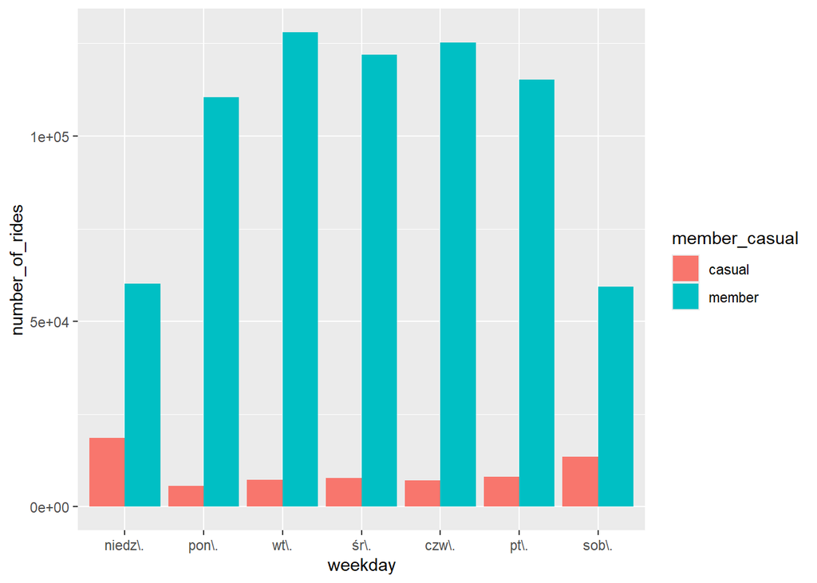

```r
all_trips_v2 |>
  mutate(weekday = wday(started_at, label = TRUE)) |>
  group_by(member_casual, weekday) |>
  summarise(number_of_rides = n(), average_duration = mean(ride_length)) |>
  arrange(member_casual, weekday) |>
  ggplot(aes(x = weekday, y = number_of_rides, fill = member_casual)) +
  geom_col(position = "dodge")
```

Now I want to see that chart but with average duration as “y”.

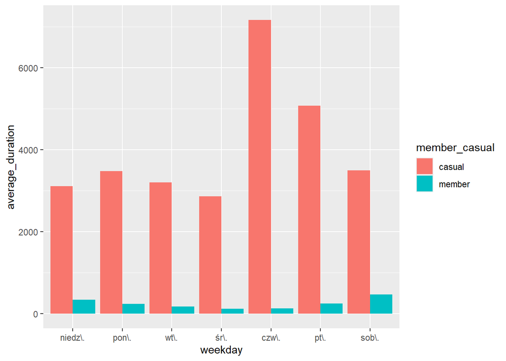

```r
all_trips_v2 |>
  mutate(weekday = wday(started_at, label = TRUE)) |>
  group_by(member_casual, weekday) |>
  summarise(number_of_rides = n(), average_duration = mean(ride_length)) |>
  arrange(member_casual, weekday) |>
  ggplot(aes(x = weekday, y = average_duration, fill = member_casual)) +
  geom_col(position = "dodge")
```

It’s interesting! We know that there are more bike rides from member users, but now we can see that they use them really small amount of time. On the other hand we see that casual users are hard users and there are no day when average duration are less than 30 minutes. Member users use bike for a really short time. We can assume that they use them in operational way (going to work) and casual more in recreational and sport way.

Creating csv file for using in other softwares.

```r
counts <- aggregate(all_trips_v2$ride_length ~ all_trips_v2$member_casual + all_trips_v2$day_of_week, FUN = mean)
write.csv(counts, file = "C:\\Users\\m.stempak\\avg_ride_length.csv")
```

Mateusz Stempak